# 1 Project: Investigate a Dataset - [Medical Appointment No Shows]

## 1.1 Table of Contents

Introduction

Data Assessing

Data Cleaning

Exploratory Data Analysis

Conclusions

## Introduction

Note: we will interpret the 1s and 0s in the dataframe in the following manner: 1 as True and 0 as False

## 1.1.2 Questions for analysis:

1. Is there a relationship between scholarship and No shows?
2. Is there a relationship between hipertension and No shows?
3. Is there a relationship between Neighbourhood and No shows ?
4. Is there a relationship between diabetes and No shows?
5. Is there a relationship between Alcoholism and No shows?
6. Is there a relationship between Handicap and No shows?
7. Is there a relationship between SMS_received and No shows?
8. Is there a relationship between age and No shows?
9. sorting the factors that affect the show up of patients in a decsending order.

```python
# Importing  pandas, numpy and matplotlib libraries

import pandas as pd
import numpy as np
import matplotlib.pyplot as plt
import seaborn as sns
%matplotlib inline
```

## Data Assessing

```python
# importing the csv file as a dataframe
df = pd.read_csv("show_appointments.csv" )
df.head()
```

|  | PatientId | AppointmentID | Gender | ScheduledDay | AppointmentDay | Age | Neighbourhood | Scholarship | Hipertension | Diabetes | Alcoholism | Handcap | SMS_received | No-show |
| --- | --- | --- | --- | --- | --- | --- | --- | --- | --- | --- | --- | --- | --- | --- |
| 0 | 2.987250e+13 | 5642903 | F | 2016-04-29T18:38:08Z | 2016-04-29T00:00:00Z | 62 | JARDIM DA PENHA | 0 | 1 | 0 | 0 | 0 | 0 | No |
| 1 | 5.589978e+14 | 5642503 | M | 2016-04-29T16:08:27Z | 2016-04-29T00:00:00Z | 56 | JARDIM DA PENHA | 0 | 0 | 0 | 0 | 0 | 0 | No |
| 2 | 4.262962e+12 | 5642549 | F | 2016-04-29T16:19:04Z | 2016-04-29T00:00:00Z | 62 | MATA DA PRAIA | 0 | 0 | 0 | 0 | 0 | 0 | No |
| 3 | 8.679512e+11 | 5642828 | F | 2016-04-29T17:29:31Z | 2016-04-29T00:00:00Z | 8 | PONTAL DE CAMBURI | 0 | 0 | 0 | 0 | 0 | 0 | No |
| 4 | 8.841186e+12 | 5642494 | F | 2016-04-29T16:07:23Z | 2016-04-29T00:00:00Z | 56 | JARDIM DA PENHA | 0 | 1 | 1 | 0 | 0 | 0 | No |

## Data Cleaning

```python
# Drop Patientid and Appointementid columns
df.drop(df.columns[[0, 1]] , axis=1 , inplace=True)
df.head()
```

|  | Gender | ScheduledDay | AppointmentDay | Age | Neighbourhood | Scholarship | Hipertension | Diabetes | Alcoholism | Handcap | SMS_received | No-show |
| --- | --- | --- | --- | --- | --- | --- | --- | --- | --- | --- | --- | --- |
| 0 | F | 2016-04-29T18:38:08Z | 2016-04-29T00:00:00Z | 62 | JARDIM DA PENHA | 0 | 1 | 0 | 0 | 0 | 0 | No |
| 1 | M | 2016-04-29T16:08:27Z | 2016-04-29T00:00:00Z | 56 | JARDIM DA PENHA | 0 | 0 | 0 | 0 | 0 | 0 | No |
| 2 | F | 2016-04-29T16:19:04Z | 2016-04-29T00:00:00Z | 62 | MATA DA PRAIA | 0 | 0 | 0 | 0 | 0 | 0 | No |
| 3 | F | 2016-04-29T17:29:31Z | 2016-04-29T00:00:00Z | 8 | PONTAL DE CAMBURI | 0 | 0 | 0 | 0 | 0 | 0 | No |
| 4 | F | 2016-04-29T16:07:23Z | 2016-04-29T00:00:00Z | 56 | JARDIM DA PENHA | 0 | 1 | 1 | 0 | 0 | 0 | No |

```python
# Discovering if there is NAN cells in the dataset
df.info()
```

```
<class 'pandas.core.frame.DataFrame'>
RangeIndex: 110527 entries, 0 to 110526
Data columns (total 12 columns):
 #   Column          Non-Null Count   Dtype
---  ------          --------------   -----
 0   Gender          110527 non-null  object
 1   ScheduledDay    110527 non-null  object
 2   AppointmentDay  110527 non-null  object
 3   Age             110527 non-null  int64
 4   Neighbourhood   110527 non-null  object
 5   Scholarship     110527 non-null  int64
 6   Hipertension    110527 non-null  int64
 7   Diabetes        110527 non-null  int64
 8   Alcoholism      110527 non-null  int64
 9   Handcap         110527 non-null  int64
 10  SMS_received    110527 non-null  int64
 11  No-show         110527 non-null  object
dtypes: int64(7), object(5)
memory usage: 10.1+ MB
```

```python
# have a look at the end of the dataframe
df.tail(100)
```

|  | Gender | ScheduledDay | AppointmentDay | Age | Neighbourhood | Scholarship | Hipertension | Diabetes | Alcoholism | Handcap | SMS_received | No-show |
| --- | --- | --- | --- | --- | --- | --- | --- | --- | --- | --- | --- | --- |
| 110427 | F | 2016-06-02T09:46:11Z | 2016-06-08T00:00:00Z | 56 | RESISTÊNCIA | 0 | 0 | 0 | 0 | 0 | 1 | No |
| 110428 | F | 2016-06-03T12:33:46Z | 2016-06-08T00:00:00Z | 8 | RESISTÊNCIA | 0 | 0 | 0 | 0 | 0 | 1 | Yes |
| 110429 | F | 2016-06-07T10:12:25Z | 2016-06-08T00:00:00Z | 44 | RESISTÊNCIA | 0 | 0 | 0 | 0 | 0 | 0 | Yes |
| 110430 | F | 2016-05-25T09:01:33Z | 2016-06-01T00:00:00Z | 57 | RESISTÊNCIA | 0 | 0 | 0 | 0 | 0 | 0 | Yes |
| 110431 | M | 2016-06-03T08:45:25Z | 2016-06-08T00:00:00Z | 12 | RESISTÊNCIA | 0 | 0 | 0 | 0 | 0 | 1 | Yes |
| ... | ... | ... | ... | ... | ... | ... | ... | ... | ... | ... | ... | ... |
| 110522 | F | 2016-05-03T09:15:35Z | 2016-06-07T00:00:00Z | 56 | MARIA ORTIZ | 0 | 0 | 0 | 0 | 0 | 1 | No |
| 110523 | F | 2016-05-03T07:27:33Z | 2016-06-07T00:00:00Z | 51 | MARIA ORTIZ | 0 | 0 | 0 | 0 | 0 | 1 | No |
| 110524 | F | 2016-04-27T16:03:52Z | 2016-06-07T00:00:00Z | 21 | MARIA ORTIZ | 0 | 0 | 0 | 0 | 0 | 1 | No |
| 110525 | F | 2016-04-27T15:09:23Z | 2016-06-07T00:00:00Z | 38 | MARIA ORTIZ | 0 | 0 | 0 | 0 | 0 | 1 | No |
| 110526 | F | 2016-04-27T13:30:56Z | 2016-06-07T00:00:00Z | 54 | MARIA ORTIZ | 0 | 0 | 0 | 0 | 0 | 1 | No |

100 rows × 12 columns

```python
# Discovering the unique values in column 'Handcap'
df["Handcap"].value_counts()
```

```
0    108286
1      2042
2       183
3        13
4         3
Name: Handcap, dtype: int64
```

**Discovering the number of unique values in the dataset**

```python
df.nunique()
```

```
Gender                 2
ScheduledDay      103549
AppointmentDay        27
Age                  104
Neighbourhood         81
Scholarship            2
Hipertension           2
Diabetes               2
Alcoholism             2
Handcap                5
SMS_received           2
No-show                2
dtype: int64
```

**convert columns[1,2] to datetime pandas object, and also convert them to date**

```python
df["ScheduledDay"] = pd.to_datetime(df["ScheduledDay"]).dt.date
print(df["ScheduledDay"])
```

```
0         2016-04-29
1         2016-04-29
2         2016-04-29
3         2016-04-29
4         2016-04-29
             ...
110522    2016-05-03
110523    2016-05-03
110524    2016-04-27
110525    2016-04-27
110526    2016-04-27
Name: ScheduledDay, Length: 110527, dtype: object
```

**check**

```python
df.head()
```

|  | Gender | ScheduledDay | AppointmentDay | Age | Neighbourhood | Scholarship | Hipertension | Diabetes | Alcoholism | Handcap | SMS_received | No-show |
| --- | --- | --- | --- | --- | --- | --- | --- | --- | --- | --- | --- | --- |
| 0 | F | 2016-04-29 | 2016-04-29T00:00:00Z | 62 | JARDIM DA PENHA | 0 | 1 | 0 | 0 | 0 | 0 | No |
| 1 | M | 2016-04-29 | 2016-04-29T00:00:00Z | 56 | JARDIM DA PENHA | 0 | 0 | 0 | 0 | 0 | 0 | No |
| 2 | F | 2016-04-29 | 2016-04-29T00:00:00Z | 62 | MATA DA PRAIA | 0 | 0 | 0 | 0 | 0 | 0 | No |
| 3 | F | 2016-04-29 | 2016-04-29T00:00:00Z | 8 | PONTAL DE CAMBURI | 0 | 0 | 0 | 0 | 0 | 0 | No |
| 4 | F | 2016-04-29 | 2016-04-29T00:00:00Z | 56 | JARDIM DA PENHA | 0 | 1 | 1 | 0 | 0 | 0 | No |

**extracting date from Appointmentday column**

```python
df["AppointmentDay"] = pd.to_datetime(df["AppointmentDay"]).dt.date
df.head()
```

|  | Gender | ScheduledDay | AppointmentDay | Age | Neighbourhood | Scholarship | Hipertension | Diabetes | Alcoholism | Handcap | SMS_received | No-show |
| --- | --- | --- | --- | --- | --- | --- | --- | --- | --- | --- | --- | --- |
| 0 | F | 2016-04-29 | 2016-04-29 | 62 | JARDIM DA PENHA | 0 | 1 | 0 | 0 | 0 | 0 | No |
| 1 | M | 2016-04-29 | 2016-04-29 | 56 | JARDIM DA PENHA | 0 | 0 | 0 | 0 | 0 | 0 | No |
| 2 | F | 2016-04-29 | 2016-04-29 | 62 | MATA DA PRAIA | 0 | 0 | 0 | 0 | 0 | 0 | No |
| 3 | F | 2016-04-29 | 2016-04-29 | 8 | PONTAL DE CAMBURI | 0 | 0 | 0 | 0 | 0 | 0 | No |
| 4 | F | 2016-04-29 | 2016-04-29 | 56 | JARDIM DA PENHA | 0 | 1 | 1 | 0 | 0 | 0 | No |

**correcting handcap to handicap**

```python
df = df.rename(columns={"Handcap": "Handicap" , "No-show" : "No_show"})
df.head()
```

|  | Gender | ScheduledDay | AppointmentDay | Age | Neighbourhood | Scholarship | Hipertension | Diabetes | Alcoholism | Handicap | SMS_received | No_show |
| --- | --- | --- | --- | --- | --- | --- | --- | --- | --- | --- | --- | --- |
| 0 | F | 2016-04-29 | 2016-04-29 | 62 | JARDIM DA PENHA | 0 | 1 | 0 | 0 | 0 | 0 | No |
| 1 | M | 2016-04-29 | 2016-04-29 | 56 | JARDIM DA PENHA | 0 | 0 | 0 | 0 | 0 | 0 | No |
| 2 | F | 2016-04-29 | 2016-04-29 | 62 | MATA DA PRAIA | 0 | 0 | 0 | 0 | 0 | 0 | No |
| 3 | F | 2016-04-29 | 2016-04-29 | 8 | PONTAL DE CAMBURI | 0 | 0 | 0 | 0 | 0 | 0 | No |
| 4 | F | 2016-04-29 | 2016-04-29 | 56 | JARDIM DA PENHA | 0 | 1 | 1 | 0 | 0 | 0 | No |

**check for duplicated rows**

```python
df.duplicated().sum()
```

```
8070
```

**check for a sample of duplicated rows**

```python
df_1 = df[df.duplicated()]
df_1.head()
```

|  | Gender | ScheduledDay | AppointmentDay | Age | Neighbourhood | Scholarship | Hipertension | Diabetes | Alcoholism | Handicap | SMS_received | No_show |
| --- | --- | --- | --- | --- | --- | --- | --- | --- | --- | --- | --- | --- |
| 52 | F | 2016-03-31 | 2016-04-29 | 23 | GRANDE VITÓRIA | 1 | 0 | 0 | 0 | 0 | 1 | Yes |
| 99 | F | 2016-04-29 | 2016-04-29 | 1 | BONFIM | 0 | 0 | 0 | 0 | 0 | 0 | No |
| 110 | F | 2016-04-12 | 2016-04-29 | 34 | SANTO ANTÔNIO | 0 | 0 | 0 | 0 | 0 | 1 | No |
| 154 | F | 2016-04-28 | 2016-04-29 | 30 | ITARARÉ | 0 | 0 | 0 | 0 | 0 | 0 | No |
| 210 | F | 2016-04-26 | 2016-04-29 | 47 | SANTOS DUMONT | 0 | 0 | 0 | 0 | 0 | 0 | No |

**drop duplicated rows**

```python
df.drop_duplicates(inplace=True)
#check
df.info(0)
```

```
<class 'pandas.core.frame.DataFrame'>
Int64Index: 102457 entries, 0 to 110526
Data columns (total 12 columns):
 #   Column          Non-Null Count   Dtype
---  ------          --------------   -----
 0   Gender          102457 non-null  object
 1   ScheduledDay    102457 non-null  object
 2   AppointmentDay  102457 non-null  object
 3   Age             102457 non-null  int64
 4   Neighbourhood   102457 non-null  object
 5   Scholarship     102457 non-null  int64
 6   Hipertension    102457 non-null  int64
 7   Diabetes        102457 non-null  int64
 8   Alcoholism      102457 non-null  int64
 9   Handicap        102457 non-null  int64
 10  SMS_received    102457 non-null  int64
 11  No_show         102457 non-null  object
dtypes: int64(7), object(5)
memory usage: 10.2+ MB
```

*From the above observation of unique values, we saw that the Handicap column has 5 unique values (0,1,2,3,4) , while the website of kaggle said that the Handicap column has only two values, which are True and False (1,0) , therefore we will consider here that the Handicap column values (2,3,4) are error values and we are going to replace these values with 1*

```python
df['Handicap'] = df['Handicap'].replace([2, 3, 4] , [1, 1, 1])
# check
df['Handicap'].unique()
```

```
array([0, 1], dtype=int64)
```

## Exploratory Data Analysis

```
array([[<AxesSubplot: title={'center': 'Age'}>,
        <AxesSubplot: title={'center': 'Scholarship'}>,
        <AxesSubplot: title={'center': 'Hipertension'}>],
       [<AxesSubplot: title={'center': 'Diabetes'}>,
        <AxesSubplot: title={'center': 'Alcoholism'}>,
        <AxesSubplot: title={'center': 'Handicap'}>],
       [<AxesSubplot: title={'center': 'SMS_received'}>, <AxesSubplot: >,
        <AxesSubplot: >]], dtype=object)
```

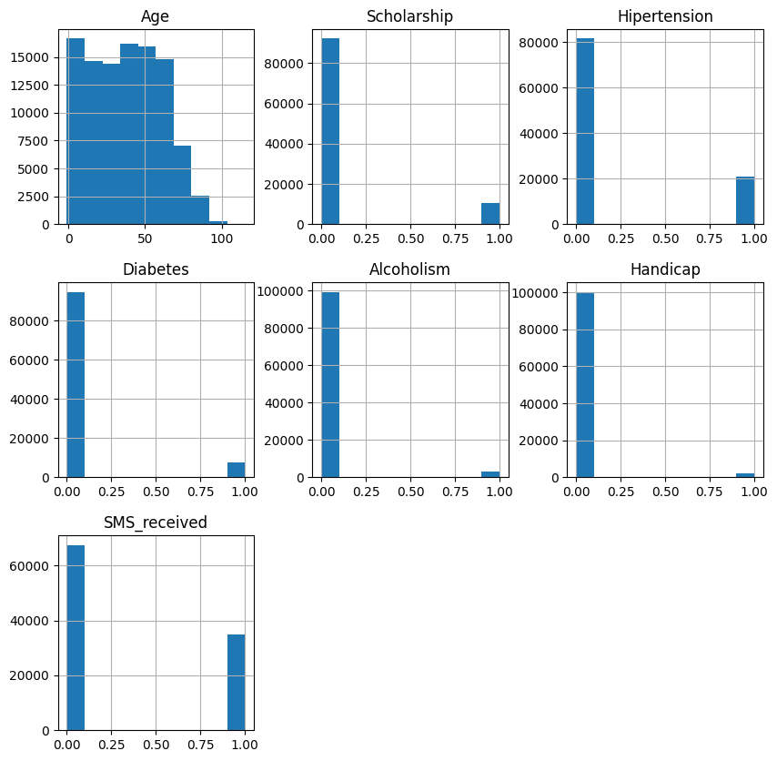

```python
# Have a look on the frequency distribution of all the columns of the table
df.hist(figsize=(10,10))
```

**This Histogram showed that for every factor suspected to be a reason for patients who no show, the number of patients not exhibiting that factor is greater than the number of patients exhibiting that factor, this means that, these factors are not highly effecting the No show state of patients.**

### 1.1.3 Is there a relationship between scholarship and No shows?

```python
df.groupby("Scholarship")["No_show"].value_counts()
```

```
Scholarship  No_show
0            No         73106
             Yes        19025
1            No          7844
             Yes         2482
Name: No_show, dtype: int64
```

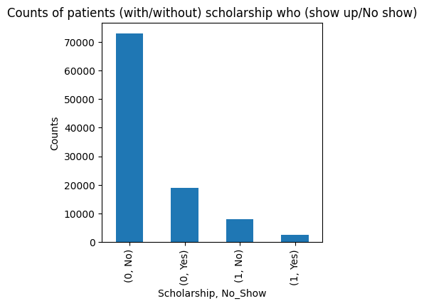

```python
df.groupby("Scholarship")["No_show"].value_counts().plot(kind='bar'  , figsize=(4,4))
plt.title("Counts of patients (with/without) scholarship who (show up/No show)")
plt.xlabel("Scholarship, No_Show")
plt.ylabel("Counts")
```

**It is seen from the above figure that the number of patients with scholarships who show up their appointment (1, No) is less than the number of patients without scholarships who don't show up their appointment (0, yes), therefore scholarship has a minor effect on show up.**

Now, we want to calculate the probability that a patient without a scholarship will No show

```python
scholarship_probability =   19025 /(19025 + 73106 )
print(scholarship_probability)
```

```
0.2064994410133397
```

Result:

Therefore, a patient without scholarship is probable to show up his scheduled appointment by (0.79/0.21) = 3.8 more times than a patient who did not show up

### 1.1.4 Is there a relationship between hipertension and No shows?

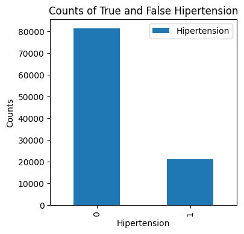

```python
df["Hipertension"].value_counts().plot(kind="bar" , figsize=(4,4));
plt.legend()
plt.title("Counts of True and False Hipertension")
plt.xlabel("Hipertension")
plt.ylabel("Counts")
```

**view the effect of Hipertension on the show up of patients on their appointments**

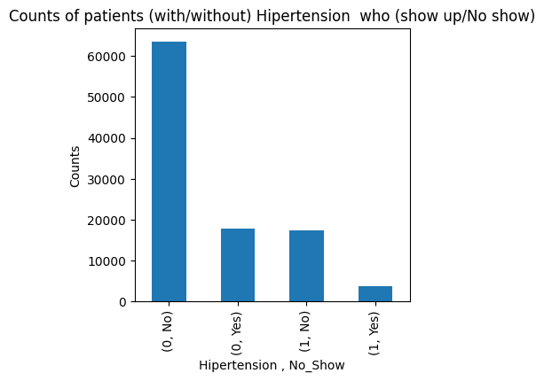

```python
df.groupby("Hipertension")["No_show"].value_counts().plot(kind='bar' , figsize=(4,4))
plt.title("Counts of patients (with/without) Hipertension  who (show up/No show)")
plt.xlabel("Hipertension , No_Show")
plt.ylabel("Counts")
```

**It is seen from the above figure that the number of patients with hipertension who don't show up their appointment (1, yes) is less than the number of patients without hipertension who show up their appointment (0, No), therefore hipertension has a minor effect on show up.**

```python
df.groupby("Hipertension")["No_show"].value_counts()
```

```
Hipertension  No_show
0             No         63629
              Yes        17834
1             No         17321
              Yes         3673
Name: No_show, dtype: int64
```

we want here to calculate the probability that a patient with Hipertension will No shows

```python
hipertension_probability = 3673/ (3673 + 17321)
print(hipertension_probability)
```

```
0.17495474897589788
```

Result:

Therefore, a patient with hipertension is probable to show up his scheduled appointment by (0.82/0.18) = 4.6 more times than a patient with no hipertension

### 1.1.5 Is there a relationship between Neighbourhood and No shows ?

**view the effect of Neighbourhood on the show up of patients on their appointments**

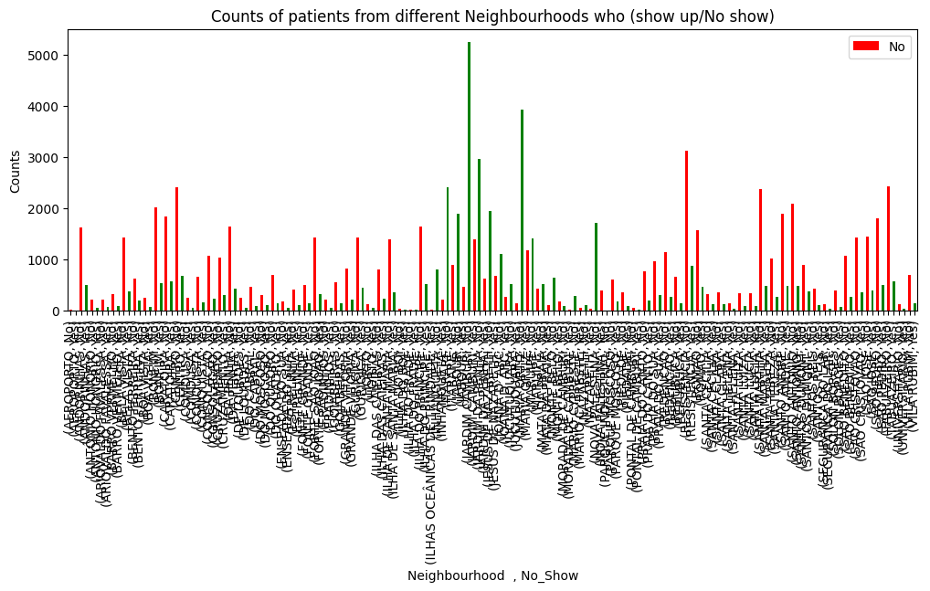

```python
df.groupby("Neighbourhood")["No_show"].value_counts().plot(kind='bar' , color=["red" , "green"] , figsize=(12,4))
plt.legend(("No","YES"))
plt.title("Counts of patients from different Neighbourhoods who (show up/No show)")
plt.xlabel("Neighbourhood  , No_Show")
plt.ylabel("Counts")
```

```python
# finding the counts of No shows for every Neighbourhood
pd.set_option('display.max_rows', None)
df.groupby("Neighbourhood")["No_show"].value_counts()
```

```
Neighbourhood                No_show
AEROPORTO                    No            7
                             Yes           1
ANDORINHAS                   No         1617
                             Yes         487
ANTÔNIO HONÓRIO              No          210
                             Yes          49
ARIOVALDO FAVALESSA          No          214
                             Yes          61
BARRO VERMELHO               No          310
                             Yes          89
BELA VISTA                   No         1414
                             Yes         368
BENTO FERREIRA               No          616
                             Yes         182
BOA VISTA                    No          248
                             Yes          58
BONFIM                       No         2006
                             Yes         536
CARATOÍRA                    No         1831
                             Yes         566
CENTRO                       No         2407
                             Yes         669
COMDUSA                      No          241
                             Yes          53
CONQUISTA                    No          652
                             Yes         153
CONSOLAÇÃO                   No         1067
                             Yes         227
CRUZAMENTO                   No         1027
                             Yes         295
DA PENHA                     No         1642
                             Yes         424
DE LOURDES                   No          250
                             Yes          47
DO CABRAL                    No          453
                             Yes          84
DO MOSCOSO                   No          304
                             Yes          91
DO QUADRO                    No          690
```

[output cut: 107 more lines]

```
SÃO BENEDITO                 No         1068
                             Yes         258
SÃO CRISTÓVÃO                No         1422
                             Yes         356
SÃO JOSÉ                     No         1433
                             Yes         394
SÃO PEDRO                    No         1800
                             Yes         494
TABUAZEIRO                   No         2415
                             Yes         558
UNIVERSITÁRIO                No          119
                             Yes          32
VILA RUBIM                   No          695
                             Yes         139
Name: No_show, dtype: int64
```

```python
# finding the Neighbourhood wiht max count of No shows
df.groupby("Neighbourhood")["No_show"].value_counts().max()
```

```
5243
```

Result:

[output not shown]

### 1.1.6 Is there a relationship between diabetes and No shows?

**view the effect of Diabetes on the show up of patients on their appointments**

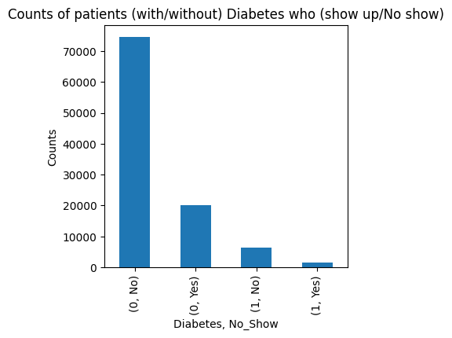

```python
df.groupby("Diabetes")["No_show"].value_counts().plot(kind='bar' , figsize=(4,4))
plt.title("Counts of patients (with/without) Diabetes who (show up/No show)")
plt.xlabel("Diabetes, No_Show")
plt.ylabel("Counts")
```

**It is seen from the above figure that the number of patients with Diabetes who don't show up their appointment (1, yes) is less than the number of patients without Diabetes who show up their appointment (0, No), therefore Diabetes has a minor effect on show up.**

```python
df.groupby("Diabetes")["No_show"].value_counts()
```

```
Diabetes  No_show
0         No         74657
          Yes        20101
1         No          6293
          Yes         1406
Name: No_show, dtype: int64
```

we want here to calculate the probability that a patient with Diabetes will No shows

```python
diabetes_probability = 1406 / (1406 + 6293)
print(diabetes_probability)
```

```
0.18262111962592545
```

Result:

Therefore, a patient with Diabetes is probable to show up his scheduled appointment by (0.82/0.18) = 4.6 more times than a patient with no Diabetes

### 1.1.7 Is there a relationship between Alcoholism and No shows?

**view the effect of Alcoholism on the show up of patients on their appointments**

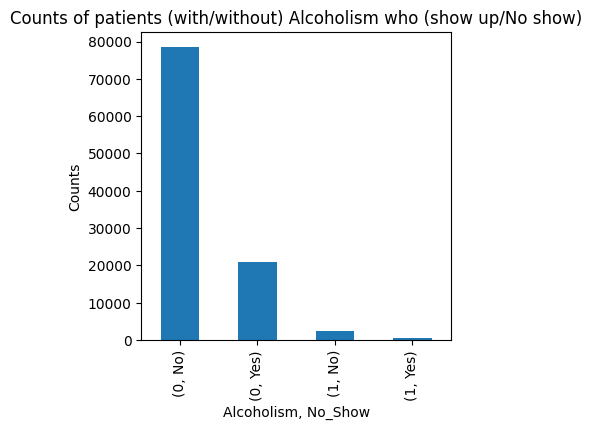

```python
df.groupby("Alcoholism")["No_show"].value_counts().plot(kind='bar' , figsize=(4,4))
plt.title("Counts of patients (with/without) Alcoholism who (show up/No show)")
plt.xlabel("Alcoholism, No_Show")
plt.ylabel("Counts")
```

**It is seen from the above figure that the number of patients with Alcoholism who don't show up their appointment (1, yes) is too less than the number of patients without Alcoholism who show up their appointment (0, No), therefore Alcoholism has a minor effect on show up.**

```python
df.groupby("Alcoholism")["No_show"].value_counts()
```

```
Alcoholism  No_show
0           No         78634
            Yes        20851
1           No          2316
            Yes          656
Name: No_show, dtype: int64
```

we want here to calculate the probability that a patient with Alcoholism will No shows

```python
alcoholism_probability =  656 / ( 656 + 2316)
print(alcoholism_probability)
```

```
0.22072678331090176
```

Result:

Therefore, a patient with alcoholism is probable to show up his scheduled appointment by (0.78/0.22) = 3.5 more times than a patient with no alcoholism.

### 1.1.8 Is there a relationship between Handicap and No shows?

**view the effect of Handicap on the show up of patients on their appointments**

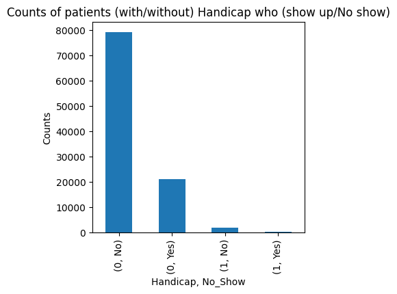

```python
df.groupby("Handicap")["No_show"].value_counts().plot(kind='bar' , figsize=(4,4))
plt.title("Counts of patients (with/without) Handicap who (show up/No show)")
plt.xlabel("Handicap, No_Show")
plt.ylabel("Counts")
```

**It is seen from the above figure that the number of patients with Handicap who don't show up their appointment (1, yes) is too less than the number of patients without Handicap who show up their appointment (0, No), therefore Handicap has a minor effect on show up.**

```python
df.groupby("Handicap")["No_show"].value_counts()
```

```
Handicap  No_show
0         No         79203
          Yes        21135
1         No          1747
          Yes          372
Name: No_show, dtype: int64
```

we want here to calculate the probability that a patient with Handicap will No shows

```python
handicap_probability = 372 / (372 + 1747)
print(handicap_probability)
```

```
0.1755545068428504
```

Result:

Therefore, a patient with Handicap is probable to show up his scheduled appointment by (0.824 / 0.176) = 4.6 more times than a patient with no Handicap.

### 1.1.9 Is there a relationship between SMS_received and No shows?

**view the effect of SMS_received on the show up of patients on their appointments**

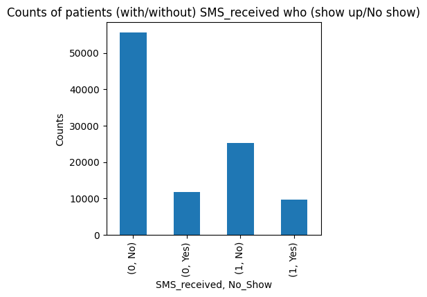

```python
df.groupby("SMS_received")["No_show"].value_counts().plot(kind='bar' , figsize=(4,4))
plt.title("Counts of patients (with/without) SMS_received who (show up/No show)")
plt.xlabel("SMS_received, No_Show")
plt.ylabel("Counts")
```

**It is seen from the above figure that the number of patients without SMS received who don't show up their appointment (0, yes) is less than the number of patients with SMS received who show up their appointment (0, No), therefore SMS received has a minor effect on show up.**

```python
df.groupby("SMS_received")["No_show"].value_counts()
```

```
SMS_received  No_show
0             No         55682
              Yes        11801
1             No         25268
              Yes         9706
Name: No_show, dtype: int64
```

we want here to calculate the probability that a patient without SMS_received will No show

```python
SMS_received_probability =  11801 / (11801 + 55682 )
print(SMS_received_probability)
```

```
0.1748736718877347
```

Result:

Therefore, a patient whithout SMS_received is probable to show up his scheduled appointment by (0.825 / 0.175) = 4.7 more times than a patient whithout SMS_received and did not show .

### 1.1.10 Is there a relationship between the age and No shows?

**viewing the unique values of age column**

```python
df["Age"].unique()
```

```
array([ 62,  56,   8,  76,  23,  39,  21,  19,  30,  29,  22,  28,  54,
        15,  50,  40,  46,   4,  13,  65,  45,  51,  32,  12,  61,  38,
        79,  18,  63,  64,  85,  59,  55,  71,  49,  78,  31,  58,  27,
         6,   2,  11,   7,   0,   3,   1,  69,  68,  60,  67,  36,  10,
        35,  20,  26,  34,  33,  16,  42,   5,  47,  17,  41,  44,  37,
        24,  66,  77,  81,  70,  53,  75,  73,  52,  74,  43,  89,  57,
        14,   9,  48,  83,  72,  25,  80,  87,  88,  84,  82,  90,  94,
        86,  91,  98,  92,  96,  93,  95,  97, 102, 115, 100,  99,  -1],
      dtype=int64)
```

```python
# replacing -1 values with 1 (suspected to be wrong value)
df['Age'] = df['Age'].replace([-1] , [1])
# check
df['Age'].unique()
```

```
array([ 62,  56,   8,  76,  23,  39,  21,  19,  30,  29,  22,  28,  54,
        15,  50,  40,  46,   4,  13,  65,  45,  51,  32,  12,  61,  38,
        79,  18,  63,  64,  85,  59,  55,  71,  49,  78,  31,  58,  27,
         6,   2,  11,   7,   0,   3,   1,  69,  68,  60,  67,  36,  10,
        35,  20,  26,  34,  33,  16,  42,   5,  47,  17,  41,  44,  37,
        24,  66,  77,  81,  70,  53,  75,  73,  52,  74,  43,  89,  57,
        14,   9,  48,  83,  72,  25,  80,  87,  88,  84,  82,  90,  94,
        86,  91,  98,  92,  96,  93,  95,  97, 102, 115, 100,  99],
      dtype=int64)
```

```python
#pd.set_option("display.max_rows", None)
# segmenting the age column values into 11 bins and add a new column age_bins to the dataframe
df['age_bins']= pd.cut(x= df['Age'] , bins = [0, 10, 20, 30, 40, 50, 60, 70, 80, 90, 100, 115])
df.head()
```

|  | Gender | ScheduledDay | AppointmentDay | Age | Neighbourhood | Scholarship | Hipertension | Diabetes | Alcoholism | Handicap | SMS_received | No_show | age_bins |
| --- | --- | --- | --- | --- | --- | --- | --- | --- | --- | --- | --- | --- | --- |
| 0 | F | 2016-04-29 | 2016-04-29 | 62 | JARDIM DA PENHA | 0 | 1 | 0 | 0 | 0 | 0 | No | (60, 70] |
| 1 | M | 2016-04-29 | 2016-04-29 | 56 | JARDIM DA PENHA | 0 | 0 | 0 | 0 | 0 | 0 | No | (50, 60] |
| 2 | F | 2016-04-29 | 2016-04-29 | 62 | MATA DA PRAIA | 0 | 0 | 0 | 0 | 0 | 0 | No | (60, 70] |
| 3 | F | 2016-04-29 | 2016-04-29 | 8 | PONTAL DE CAMBURI | 0 | 0 | 0 | 0 | 0 | 0 | No | (0, 10] |
| 4 | F | 2016-04-29 | 2016-04-29 | 56 | JARDIM DA PENHA | 0 | 1 | 1 | 0 | 0 | 0 | No | (50, 60] |

**view the effect of age on the show up of patients on their appointments**

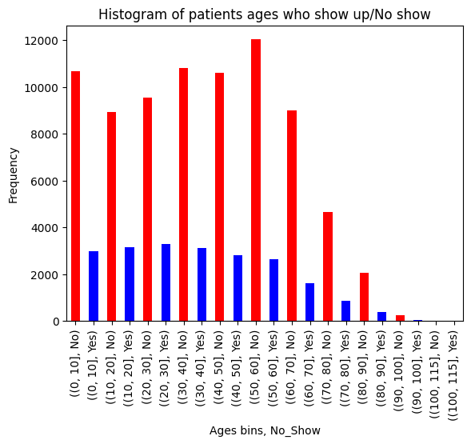

```python
df.groupby('age_bins')["No_show"].value_counts().plot(kind="bar" , color=["red" , "blue"])
plt.title("Histogram of patients ages who show up/No show")
plt.xlabel("Ages bins, No_Show")
plt.ylabel("Frequency")
```

**It is seen from the above figure that patients with all ages who don't show up (yes) are less than those who show up (No), therefore we can not say that age may be a factor affecting the the show up state of patients.**

```python
df.groupby('age_bins')["No_show"].value_counts()
```

```
age_bins    No_show
(0, 10]     No         10687
            Yes         2996
(10, 20]    No          8928
            Yes         3144
(20, 30]    No          9544
            Yes         3301
(30, 40]    No         10822
            Yes         3124
(40, 50]    No         10600
            Yes         2795
(50, 60]    No         12031
            Yes         2647
(60, 70]    No          9010
            Yes         1602
(70, 80]    No          4649
            Yes          864
(80, 90]    No          2055
            Yes          390
(90, 100]   No           231
            Yes           56
(100, 115]  No             4
            Yes            2
Name: No_show, dtype: int64
```

Result:

It is seen from the above output cell that the highest count of patients who did not show up lies in the age interval [20 , 30] , and their count decreases from 60 years upto 115 years

### 1.1.11 sorting the factors that affect NO show of patients in a decsending order.

```python
# making a dataframe for diferent probabilities found in this study
dict = { "Alcoholism" :  [0.22],
         "scholarship" : [0.21],
         "Hipertension": [0.18] ,
          "Diabetes"   : [0.18] ,
          "Handicap"   : [0.18] ,
          "SMS_received" : [0.175] }
probabilities = pd.DataFrame(dict)
print(probabilities)
```

```
   Alcoholism  scholarship  Hipertension  Diabetes  Handicap  SMS_received
0        0.22         0.21          0.18      0.18      0.18         0.175
```

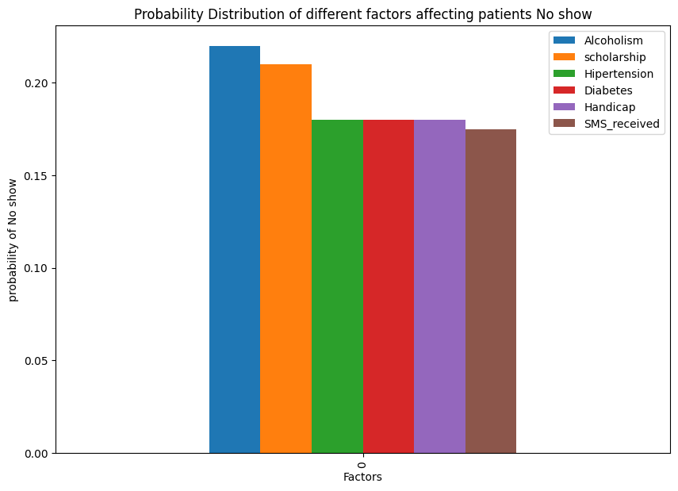

```python
probabilities.plot(kind = "bar" , figsize= (10,7))
plt.title("Probability Distribution of different factors affecting patients No show")
plt.xlabel("Factors")
plt.ylabel("probability of No show")
```

## Conclusion

**The main objective of this Dataset investigation was to find what probable factors may influence the show up of patients at their scheduled appointment. For this intent, eight factors were analysed in this study to find their associated probabilities in the show up of patients at their scheduled appointment. The results of this study can be summarized in the following Bar plot of the probabilities of different factors influencing the show up of patients at theit appointment.**

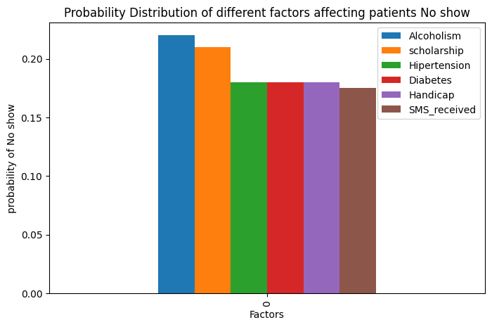

```python
probabilities.plot(kind = "bar" , figsize= (8,5))
plt.title("Probability Distribution of different factors affecting patients No show")
plt.xlabel("Factors")
plt.ylabel("probability of No show")
```

**with respect to the age factor:**

**It was seen that the highest count of patients who did not show up lies in the age interval [20 , 30] , and their count decreases from 60 years upto 115 years.**

## Limitations

**1- We have assumed that the values (2, 3, 4) given in column [Handicap] are errors, and we replaced it with the value 1. This may bias the calculated probability of patients with Handicap who No show towards higher values than reality.**

**2- The analysis made here is based on the calculation of probabilities, Probability is the mathematical calculation that evaluates the possibilities that exist for an event to happen when chance intervenes. Therefore, these calculations are just to predict and to compare what factors may render patients don't show up their appointment day. It does not tell us that any of the factors mentioned in this analysis is a real cause of a patient who don't show up.**